# Sunspot Umbra / Pore Evolution Model

Analysis report — the original FORTRAN model and its validated Python port

Author

David J Jackson

Published

August 27, 2026

[figure not shown]

## 1 Executive summary

`sun.f` is a FORTRAN 77 program Rodney wrote to model how sunspot **umbra** (dark core) and **penumbra** (surrounding lighter region) evolve day to day, driven by real observations from the Royal Greenwich Observatory. It has been ported to a Python package, `sunmodel`, with a command-line interface and a JupyterLab notebook wrapper.

This report:

1. summarizes what the original model computes and how,
2. runs the Python port end-to-end against the real input data, and
3. **verifies live, in this document,** that the port reproduces the original gfortran output exactly, row for row.

See `SUN_F_ANALYSIS.pdf` in this repository for an exhaustive, line-by-line walkthrough of the original FORTRAN source.

## 2 Background: what the model computes

The program combines two loosely-coupled sub-models:

- **An empirical, saturating growth curve** (`EXPO`/`ENERGY`/`MASS`/`JTEMP`/`E2` in the original; `sunmodel.empirical` in the port) — a hand-fit function of elapsed time with no documented physical derivation, intended to estimate a likelihood of pore evolution.
- **A small SEIR (Susceptible/Exposed/Infected/Removed) submodel** over 8 solar-disk “polygon” regions (`SPUR`/`ZCELLS`/`MOVES` in the original; `sunmodel.seir` in the port) — borrowed wholesale from an epidemiological model and repurposed to represent how “infection” (spot state) might spread between regions.

Both feed a per-day estimate of umbra (`SUSQI`) and sunspot/pore count (`SUSQS`), computed record-by-record from daily observations and written to a CSV report. The user supplies five calibration values up front: the number of umbra seen, total sunspots seen, and three percentages (umbra-with-penumbra, sunspots-in-umbra, umbra-area-to-group-area).

**NoteAn important caveat, found while porting**

Tracing the original control flow shows the SEIR/`EXPO` branch only ever executes **once**, on the very first data record of the entire run (`K=1` is hardcoded, and the loop counter it gates never resets across batches). Worse, the line that would apply `EXPO`’s result to the output (`POSQ=F*POSQ`) is commented out in `sun.f` — so that call’s result is computed but never used. In practice, the numbers in `SUN.CSV` are driven almost entirely by the simpler `1/IREC` decay term and the raw per-record `ICUA`/`ICWSA` values, not by the more elaborate curve-fit or SEIR machinery. The Python port reproduces this behavior exactly (including calling `expo()` and discarding its result) for numerical fidelity, but it’s worth knowing when interpreting the results below.

## 3 Data

| File | Role |
| --- | --- |
| `rgo_data.prn` | Daily sunspot group observations (group id, day, whole-spot area, umbra area, …) |
| `polypara.dat` | Initial S/E/I/R state and rate constants for the 8 SEIR “polygon” regions |
| `SUN.CSV` | Reference output from a real `gfortran` compile-and-run of `sun.f`, checked into this repo |

## 4 The Python port

**Imports**

```python
import pandas as pd
import matplotlib.pyplot as plt

from sunmodel import RunConfig, SunReport, SunSimulation, read_report_rows
```

`sunmodel` mirrors the original’s structure module-for-module:

| Module | Ports |
| --- | --- |
| `empirical.py` | `EXPO`, `ENERGY`, `MASS`, `JTEMP`, `E2` |
| `seir.py` | `SPUR`, `ZCELLS`, `MOVES`, `ran2` (replaced with `random.Random`) |
| `rgo_data.py` | the `rgo_data.prn` reader |
| `report.py` | the `SUN.CSV` writer |
| `simulation.py` | the main batch-driven loop |
| `cli.py` / `main.py` | the interactive prompts |

## 5 Live demonstration

Running the port against the real data files, with the same five parameters recorded in the checked-in `SUN.CSV` (4 umbra seen, 27 total sunspots, delta=0.40, gamma=0.60, P=0.30):

**Run the full simulation**

```python
import tempfile
from pathlib import Path

config = RunConfig(
    n_umbra_seen=4, n_sunspots_seen=27,
    penumbra_pct=0.40, umbra_sunspot_pct=0.60, umbra_group_area_pct=0.30,
)

scratch_csv = Path(tempfile.mkstemp(suffix=".csv")[1])
with SunReport(scratch_csv) as report:
    sim = SunSimulation(config, "rgo_data.prn", "polypara.dat", report, seed=0)
    while sim.run_batch():
        pass

npores, nspots = sim.pore_summary()
print(f"Sunspots = {sim.total_sunspots}   Pores = {npores}   Actual sunspots = {nspots}")
```

```
Sunspots = 27   Pores = 11   Actual sunspots = 16
```

```python
results = pd.DataFrame(read_report_rows(scratch_csv))
pd.concat([results.head(5), results.tail(5)])
```

Table 1: Per-day model output (first and last 5 rows)

|  | day | umbra | pores | cwsa | cua |
| --- | --- | --- | --- | --- | --- |
| 0 | 1 | 0.6731 | 8.1978 | 10 | 50 |
| 1 | 1 | 15.3357 | 2.0628 | 2 | 10 |
| 2 | 1 | 10.9541 | 10.3955 | 14 | 70 |
| 3 | 1 | 8.5198 | 10.3970 | 14 | 70 |
| 4 | 1 | 6.9708 | 24.1886 | 93 | 550 |
| 77 | 30 | 0.4884 | 11.3507 | 16 | 80 |
| 78 | 30 | 0.4823 | 12.2212 | 18 | 90 |
| 79 | 30 | 0.4763 | 6.9168 | 8 | 40 |
| 80 | 30 | 0.4704 | 20.4072 | 52 | 310 |
| 81 | 30 | 0.4647 | 5.4877 | 6 | 30 |

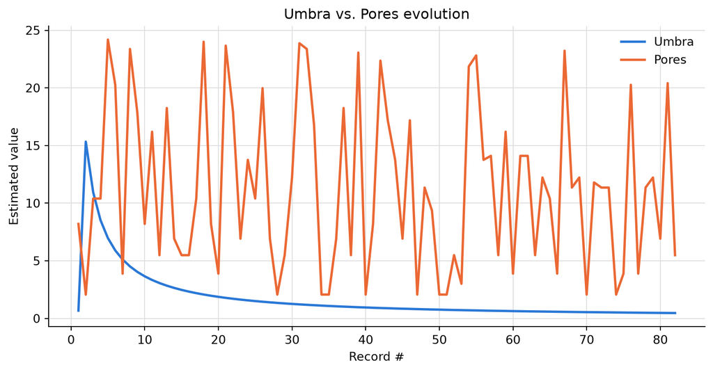

Figure 1: Umbra vs. Pores evolution across all 82 observed records

```python
# Colors are slots 1 (blue) and 2 (orange) of the project's validated
# categorical palette -- fixed hue order, not cycled, single shared axis
# since both series are the same kind of derived quantity.
UMBRA_COLOR = "#2a78d6"
PORES_COLOR = "#eb6834"

fig, ax = plt.subplots()
x = range(1, len(results) + 1)
ax.plot(x, results["umbra"], color=UMBRA_COLOR, linewidth=2, label="Umbra")
ax.plot(x, results["pores"], color=PORES_COLOR, linewidth=2, label="Pores")
ax.set_xlabel("Record #")
ax.set_ylabel("Estimated value")
ax.set_title("Umbra vs. Pores evolution")
ax.grid(True, color="#dddddd", linewidth=0.7)
for spine in ("top", "right"):
    ax.spines[spine].set_visible(False)
ax.legend(frameon=False)
fig.tight_layout()
plt.show()
```

## 6 Validation

The claim that this port is faithful isn’t just asserted — it’s checked against the real `gfortran`-produced `SUN.CSV` right here, live:

```python
reference_rows = read_report_rows("SUN.CSV")
ported_rows = read_report_rows(scratch_csv)

matches = reference_rows == ported_rows
print(f"Reference rows: {len(reference_rows)}")
print(f"Ported rows:    {len(ported_rows)}")
print(f"Byte-for-byte match: {matches}")

assert matches, "Ported output diverged from the reference FORTRAN output"
```

```
Reference rows: 82
Ported rows:    82
Byte-for-byte match: True
```

This same comparison is also encoded as a permanent regression test in `tests/test_simulation.py`, run on every change via `pytest`.

## 7 Discussion

- The model’s headline behavior — a decaying “Umbra” estimate and a noisy “Pores” estimate that tracks raw observed spot area — is driven almost entirely by simple arithmetic on the input data (`1/IREC` decay, direct scaling by `ICUA`/`ICWSA`), **not** by the more sophisticated empirical curve-fit or SEIR submodels those variable names suggest. See the callout in [Background] above.
- The SEIR submodel (`ZCELLS`/`SPUR`) is fully ported and unit-tested, and produces sensible, bounded, finite output — but it currently only contributes to the very first record of a run, and even that contribution is a smaller `POSQ` term rather than a persistent evolving state (since `ZCELLS` is always called with `timestep=0`, it re-reads `polypara.dat` fresh each time rather than carrying state forward).

**Update:** the two behavioral recommendations below (SEIR/`EXPO` actually driving output, and a decay that doesn’t depend on raw record count) are now implemented as an opt-in **`robust`** dynamics mode, alongside the original **`legacy`** mode described above. Nothing above this note changes for `legacy` mode — it remains byte-for-byte identical to `sun.f`’s output (see Validation) and stays the default in `sunmodel.cli` and `SunSimulation`, so existing workflows and the `SUN.CSV` comparison are unaffected unless `--dynamics robust` (or `dynamics="robust"`) is requested explicitly.

## 8 Recommendations / future work

- **Decide whether the SEIR/`EXPO` machinery should actually drive output.** **Done, opt-in.** `robust` mode carries `ZCELLS`’ polygon state forward across every record instead of reinitializing it, and applies `EXPO`’s result to `POSQ` (the original’s commented-out `POSQ=F*POSQ`) on every record rather than discarding it. See `SunSimulation._robust_posq` in `sunmodel/simulation.py` and `tests/test_simulation_robust.py`.
- **Consider replacing `1/IREC` decay** **Done, opt-in.** `robust` mode’s `remq` term now decays with elapsed *calendar* days since the run’s first record (`SunSimulation._robust_remq`), rather than with how many records the process happened to have handled. This matters in practice: `rgo_data.prn`’s own `Day` column jumps from day 2 to day 26 partway through the bundled sample, a 24-day gap the old `1/IREC` count couldn’t see. A run started mid-dataset (or resumed) now reproduces the trajectory a continuous run would have from that point on. The half-life of that decay (default 14 days) has no physical derivation — same caveat as `EXPO`’s curve — and is a constructor parameter (`remq_half_life_days`) for anyone who wants to tune it.
- **Run against the full historical RGO dataset**, not just the 82-record sample bundled here, to see the model’s longer-run behavior. *(Still open — needs a larger RGO extract than what’s checked into this repo.)*
- **Add a proper scientific validation** — compare model output against published sunspot umbra/penumbra ratios from the Bogdan et al. (2004) paper the original cites, beyond just confirming the port matches the original code’s arithmetic. *(Still open — needs that paper’s reference figures.)*

## 9 Appendix

- Source: `sun.f` · line-by-line walkthrough: `SUN_F_ANALYSIS.pdf`
- Python port: `sunmodel/` · tests: `tests/`
- Interactive notebook: `Sun_Model.ipynb`
- Repository: https://github.com/davidjayjackson/rodney_fortran_sun